# Tanav_BicycleSharingActivity

Tanav Thanjavuru

3/15/2021

# Set Up

### Clean up environment and load packages

```r
# clean up the RStudio environment
rm(list = ls())

# load all packages here: `mosaic`, `tidyverse`, `lubridate`, and all others used
library(mosaic)
library(tidyverse)
library(lubridate)
```

### Data Intake

Finish the code chunk below to load the data for you. It is mostly complete, but you need to read the CSV of the `Stations` data into R as shown in the book.

```r
### Load the station data set into our RStudio environment as described in the text
station_url <- "https://mdbeckman.github.io/dcSupplement/data/DC-Stations.csv"
Stations <- readr::read_csv(station_url)
### Load the station data set into our RStudio environment as described in the text

trip_url <- "https://mdbeckman.github.io/dcSupplement/data/Trips-History-Data-2014-Q4-Small.rds"  # small data: 10k rows
# trip_url <- "https://mdbeckman.github.io/dcSupplement/data/Trips-History-Data-2014-Q4.rds"      # full data: 600k rows

Trips <- readRDS(gzcon(url(trip_url)))


### Backup code if you need to download the .rds file from the web and load a local version

# Trips <- readRDS("2014-Q4-Trips-History-Data-Small.rds")   # small data: 10k rows
# Trips <- readRDS("2014-Q4-Trips-History-Data.rds")         # full data: 600k rows
```

### Always inspect the data tables when you load them

```r
head(Stations)
```

| name | lat | long | nbBikes | nbEmptyDocks |
| --- | --- | --- | --- | --- |
| 20th & Bell St | 38.85610 | -77.05120 | 7 | 4 |
| 18th & Eads St. | 38.85725 | -77.05332 | 8 | 3 |
| 20th & Crystal Dr | 38.85640 | -77.04920 | 8 | 7 |
| 15th & Crystal Dr | 38.86017 | -77.04959 | 9 | 2 |
| Aurora Hills Community Ctr/18th & Hayes St | 38.85787 | -77.05949 | 7 | 4 |
| Pentagon City Metro / 12th & S Hayes St | 38.86230 | -77.05994 | 7 | 12 |

```r
glimpse(Stations)
```

```
Rows: 347
Columns: 5
$ name         <chr> "20th & Bell St", "1…
$ lat          <dbl> 38.85610, 38.85725, …
$ long         <dbl> -77.05120, -77.05332…
$ nbBikes      <dbl> 7, 8, 8, 9, 7, 7, 5,…
$ nbEmptyDocks <dbl> 4, 3, 7, 2, 4, 12, 6…
```

```r
head(Trips)
```

| duration | sdate | sstation | edate | estation | bikeno | client |
| --- | --- | --- | --- | --- | --- | --- |
| 0h 5m 32s | 2014-10-15 08:58:00 | Braddock Rd Metro | 2014-10-15 09:04:00 | Commerce St & Fayette St | W21555 | Casual |
| 0h 10m 18s | 2014-12-18 09:17:00 | 10th & Florida Ave NW | 2014-12-18 09:27:00 | 21st St & Pennsylvania Ave NW | W20694 | Registered |
| 0h 5m 11s | 2014-10-14 18:58:00 | Eastern Market Metro / Pennsylvania Ave & 7th St SE | 2014-10-14 19:03:00 | Potomac & Pennsylvania Ave SE | W00035 | Registered |
| 0h 15m 2s | 2014-10-24 18:09:00 | New Jersey Ave & R St NW | 2014-10-24 18:24:00 | Columbia Rd & Belmont St NW | W01288 | Registered |
| 0h 2m 51s | 2014-10-04 20:17:00 | 12th & Irving St NE | 2014-10-04 20:20:00 | 10th & Monroe St NE | W01296 | Registered |
| 0h 6m 59s | 2014-11-08 15:33:00 | 15th & F St NE | 2014-11-08 15:40:00 | 6th & H St NE | W01251 | Registered |

```r
glimpse(Trips)
```

```
Rows: 10,000
Columns: 7
$ duration <chr> "0h 5m 32s", "0h 10m 18s…
$ sdate    <dttm> 2014-10-15 08:58:00, 20…
$ sstation <chr> "Braddock Rd Metro", "10…
$ edate    <dttm> 2014-10-15 09:04:00, 20…
$ estation <chr> "Commerce St & Fayette S…
$ bikeno   <chr> "W21555", "W20694", "W00…
$ client   <chr> "Casual", "Registered", …
```

### Plot check-out times. (reproduce Figure 18.1: Use of shared bicycles over the three months in Q4.)

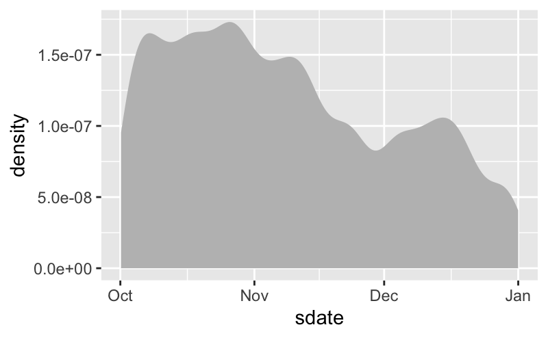

```r
Trips %>%
  ggplot(aes(x = sdate)) +
  geom_density(fill = "gray", color = NA)
```

# Section: How Long?

Make box & whisker plot showing the distribution of rental duration by client type. As instructed in the text, make sure you either configure your scale or use a filter to suppress outliers from dictating the axis range.

```r
durationhour <-
  Trips %>%
  mutate(durationhour = as.numeric(edate - sdate)/60)
```

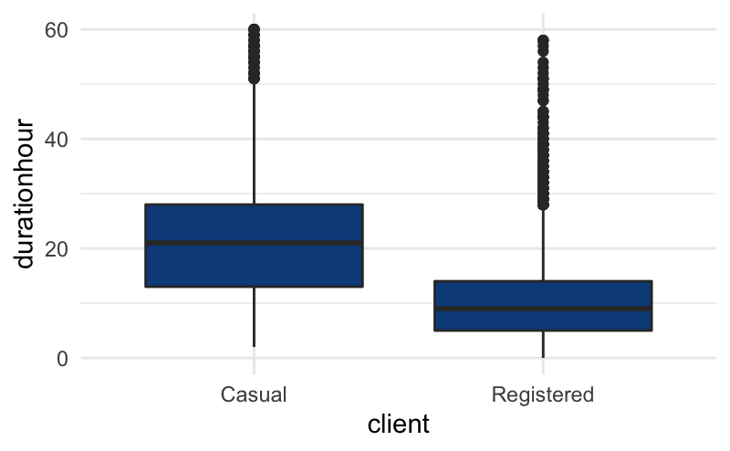

```r
ggplot(durationhour) +
 aes(x = client, y = durationhour) +
 geom_boxplot(fill = "#0c4c8a") +
  ylim(0,60) +
 theme_minimal()
```

# Section: When are bikes used?

Note: You’ll use several functions that begin with `lubridate::` this means that those functions have come from the `lubridate` R package, which makes it easy to work with dates in R. The activity template instructed you to load this package already, but you should use Google or the RStudio help to get a sense of the kind of things this package is designed to do.

##### Day of the year (1 to 365)

```r
day <-
  Trips %>%
  mutate(day = lubridate:: yday(sdate)) %>%
  select(sdate,day)
  head(day)
```

| sdate | day |
| --- | --- |
| 2014-10-15 08:58:00 | 288 |
| 2014-12-18 09:17:00 | 352 |
| 2014-10-14 18:58:00 | 287 |
| 2014-10-24 18:09:00 | 297 |
| 2014-10-04 20:17:00 | 277 |
| 2014-11-08 15:33:00 | 312 |

```r
NA
```

##### Day of the week (Sunday to Saturday)

```r
dayofweek <-
  Trips %>%
  mutate(week = lubridate:: wday(sdate)) %>%
  select(sdate,week)
  head(dayofweek)
```

| sdate | week |
| --- | --- |
| 2014-10-15 08:58:00 | 4 |
| 2014-12-18 09:17:00 | 5 |
| 2014-10-14 18:58:00 | 3 |
| 2014-10-24 18:09:00 | 6 |
| 2014-10-04 20:17:00 | 7 |
| 2014-11-08 15:33:00 | 7 |

```r
NA
NA
```

##### Hour of the day (0 to 24)

```r
hourofday <-
  Trips %>%
  mutate(hour = lubridate:: hour(sdate)) %>%
  select(sdate,hour)
  head(hourofday)
```

| sdate | hour |
| --- | --- |
| 2014-10-15 08:58:00 | 8 |
| 2014-12-18 09:17:00 | 9 |
| 2014-10-14 18:58:00 | 18 |
| 2014-10-24 18:09:00 | 18 |
| 2014-10-04 20:17:00 | 20 |
| 2014-11-08 15:33:00 | 15 |

```r
NA
```

##### Minute in the hour (0 to 60)

```r
minutesinhour <-
  Trips %>%
  mutate(minutes = lubridate:: minute(sdate)) %>%
  select(sdate,minutes)
  head(minutesinhour)
```

| sdate | minutes |
| --- | --- |
| 2014-10-15 08:58:00 | 58 |
| 2014-12-18 09:17:00 | 17 |
| 2014-10-14 18:58:00 | 58 |
| 2014-10-24 18:09:00 | 9 |
| 2014-10-04 20:17:00 | 17 |
| 2014-11-08 15:33:00 | 33 |

```r
NA
```

### Group the bike rentals by hour, weekday, & client type

```r
hwc <-
  Trips %>%
  mutate(hour = lubridate:: hour(sdate)) %>%
  mutate(week = lubridate:: wday(sdate)) %>%
  group_by(hour, week, client)
  head(hwc)
```

| duration | sdate | sstation | edate | estation | bikeno | client | hour | week |
| --- | --- | --- | --- | --- | --- | --- | --- | --- |
| 0h 5m 32s | 2014-10-15 08:58:00 | Braddock Rd Metro | 2014-10-15 09:04:00 | Commerce St & Fayette St | W21555 | Casual | 8 | 4 |
| 0h 10m 18s | 2014-12-18 09:17:00 | 10th & Florida Ave NW | 2014-12-18 09:27:00 | 21st St & Pennsylvania Ave NW | W20694 | Registered | 9 | 5 |
| 0h 5m 11s | 2014-10-14 18:58:00 | Eastern Market Metro / Pennsylvania Ave & 7th St SE | 2014-10-14 19:03:00 | Potomac & Pennsylvania Ave SE | W00035 | Registered | 18 | 3 |
| 0h 15m 2s | 2014-10-24 18:09:00 | New Jersey Ave & R St NW | 2014-10-24 18:24:00 | Columbia Rd & Belmont St NW | W01288 | Registered | 18 | 6 |
| 0h 2m 51s | 2014-10-04 20:17:00 | 12th & Irving St NE | 2014-10-04 20:20:00 | 10th & Monroe St NE | W01296 | Registered | 20 | 7 |
| 0h 6m 59s | 2014-11-08 15:33:00 | 15th & F St NE | 2014-11-08 15:40:00 | 6th & H St NE | W01251 | Registered | 15 | 7 |

```r
NA
```

### Construct a similar plot using density rather than frequency

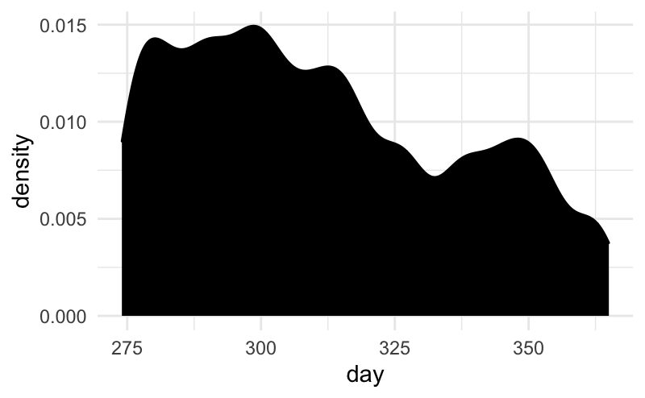

```r
ggplot(day) +
 aes(x = day) +
 geom_density(adjust = 1L, fill = "#000000") +
 theme_minimal()
```

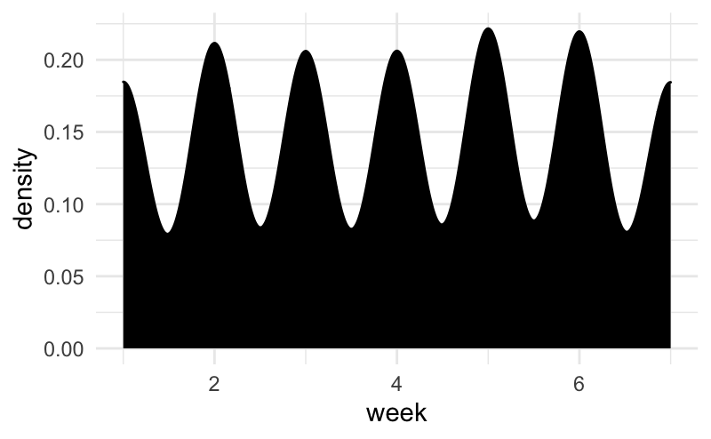

```r
ggplot(dayofweek) +
 aes(x = week) +
 geom_density(adjust = 1L, fill = "#000000") +
 theme_minimal()
```

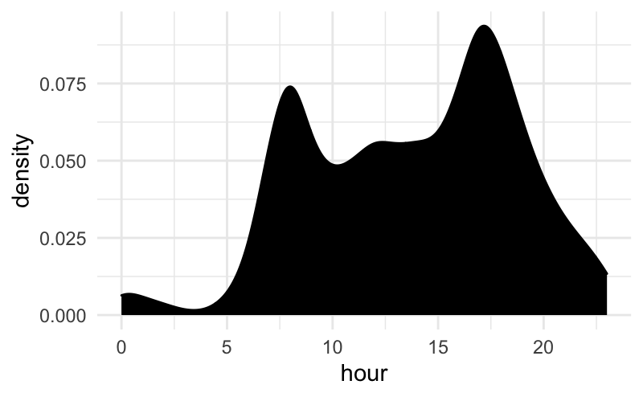

```r
ggplot(hourofday) +
 aes(x = hour) +
 geom_density(adjust = 1L, fill = "#000000") +
 theme_minimal()
```

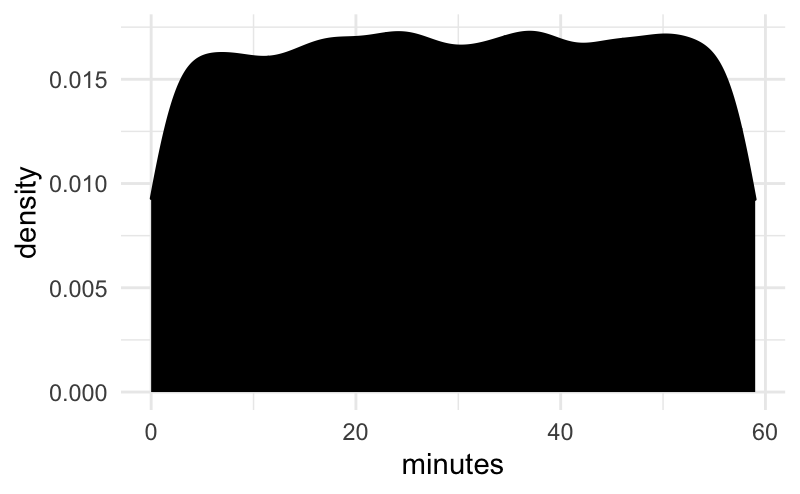

```r
ggplot(minutesinhour) +
 aes(x = minutes) +
 geom_density(adjust = 1L, fill = "#000000") +
 theme_minimal()
```

# Section: How Far?

We want to calculate the distance between stations using the `haversine()` function. The `source()` function actually runs an R script found at the provided location. Use a web browser to visit this URL and read about the function (it’s only a few lines).

```r
source("https://mdbeckman.github.io/dcSupplement/R/haversine.R")
```

```r
Simple <-
  Stations %>%
  select(name, lat, long) %>%
  rename(sstation = name)

Simple2 <-
  Simple %>%
  rename(estation = sstation, lat2 = lat, long2 = long)

merge(head(Simple, 4), head(Simple2, 3), by = NULL)
```

| sstation | lat | long | estation | lat2 | long2 |
| --- | --- | --- | --- | --- | --- |
| 20th & Bell St | 38.85610 | -77.05120 | 20th & Bell St | 38.85610 | -77.05120 |
| 18th & Eads St. | 38.85725 | -77.05332 | 20th & Bell St | 38.85610 | -77.05120 |
| 20th & Crystal Dr | 38.85640 | -77.04920 | 20th & Bell St | 38.85610 | -77.05120 |
| 15th & Crystal Dr | 38.86017 | -77.04959 | 20th & Bell St | 38.85610 | -77.05120 |
| 20th & Bell St | 38.85610 | -77.05120 | 18th & Eads St. | 38.85725 | -77.05332 |
| 18th & Eads St. | 38.85725 | -77.05332 | 18th & Eads St. | 38.85725 | -77.05332 |
| 20th & Crystal Dr | 38.85640 | -77.04920 | 18th & Eads St. | 38.85725 | -77.05332 |
| 15th & Crystal Dr | 38.86017 | -77.04959 | 18th & Eads St. | 38.85725 | -77.05332 |
| 20th & Bell St | 38.85610 | -77.05120 | 20th & Crystal Dr | 38.85640 | -77.04920 |
| 18th & Eads St. | 38.85725 | -77.05332 | 20th & Crystal Dr | 38.85640 | -77.04920 |

[output cut: 2 more lines]

```r
StationPairs <- merge(Simple, Simple2, by = NULL)
```

```r
PairDistances <-
  StationPairs %>%
  mutate(distance = haversine(lat, long, lat2, long2)) %>%
  select(sstation, estation, distance)
```

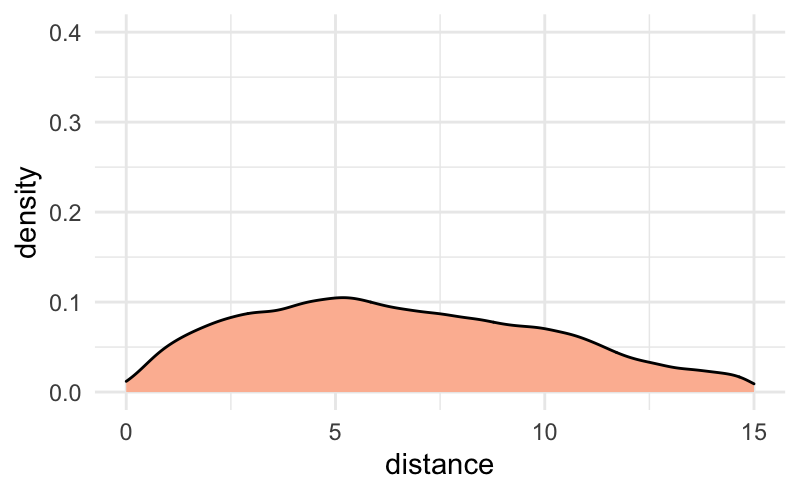

```r
ggplot(PairDistances) +
 aes(x = distance) +
 geom_density(adjust = 1L, fill = "#fcbba1") +
 theme_minimal() +
 xlim(0L, 15L) +
  ylim(0,0.4)
```

```r
TripDistance <-
  Trips %>%
  inner_join(PairDistances, by = c("sstation" = "sstation", "estation" = "estation")) %>%
  select(sstation, estation, distance)
```

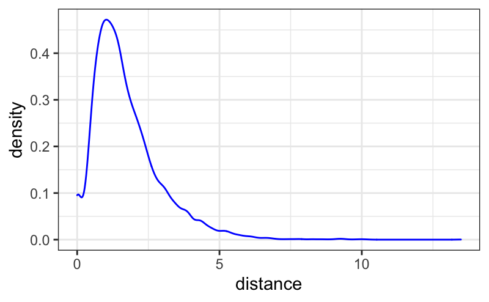

```r
ggplot(TripDistance) +
 aes(x = distance) +
 geom_density(adjust = 1L, color = "blue") +
 theme_bw()
```

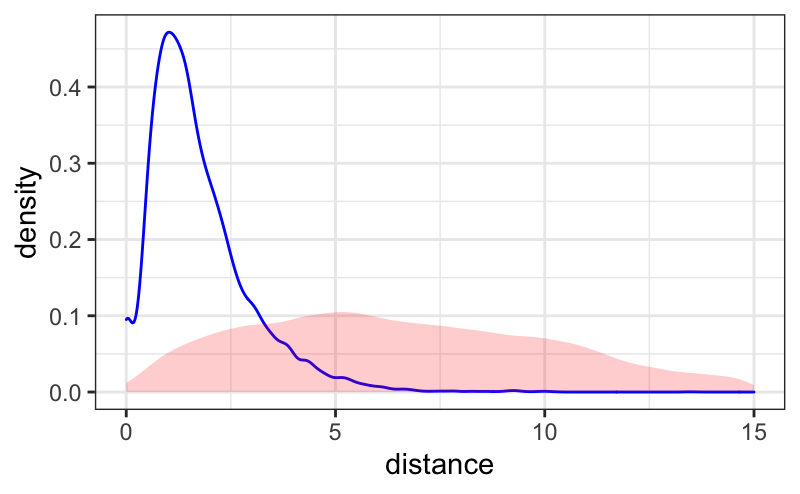

```r
TripDistance %>%
  ggplot() +
 aes(x = distance) +
 geom_density(aes(x = distance), color = "blue") +
 geom_density(data = PairDistances, aes(x = distance), color = NA, fill = "red", alpha = 0.2) +
  theme_bw() +
  xlim(0L, 15L)
```

# Section: Mapping the Stations

```r
library(leaflet)
stationMap <-
  leaflet(Stations) %>%           # like ggplot()
  addTiles() %>%                  # add the map
  addCircleMarkers(radius = 2, color = "red") %>%
  addCircleMarkers(radius = ~ mid, color = "blue", opacity = 0.0001) %>%
  setView(-77.04, 38.9, zoom = 12)
```

```
Assuming "long" and "lat" are longitude and latitude, respectively
Assuming "long" and "lat" are longitude and latitude, respectively
```

```r
stationMap
```

[interactive chart not shown]

# Section: Long-distance stations (Extra Credit)